# Machine Learning Peer Assessment

## Summary

The goal of your project is to predict the manner in which they did the exercise. This is the “classe” variable in the training set. You may use any of the other variables to predict with. You should create a report describing how you built your model, how you used cross validation, what you think the expected out of sample error is, and why you made the choices you did. You will also use your prediction model to predict 20 different test cases.

### Downloading data and library

First we load the libraries we are going to use.

```r
library(ggplot2)
library(lattice)
library(corrplot)
library(caret)
library(randomForest)
```

### Downloading and loading data files

We download the files: pml-training.csv and plm-testing.csv data and the quiz to train our model if we didnt downloaded them before. Them we load these files to work with them.

```r
if (!file.exists ("pml-training.csv" )) {
 download.file ("https://d396qusza40orc.cloudfront.net/predmachlearn/pml-training.csv",
    destfile="pml-training.csv" )
}

if (!file.exists ("pml-testing.csv")){
 download.file ("https://d396qusza40orc.cloudfront.net/predmachlearn/pml-testing.csv",
    destfile="pml-testing.csv")
}


data <- read.csv("~/pml-training.csv")
quiz  <- read.csv("~/pml-testing.csv")
```

### Understanding data and creating training and testing subsets

```r
names(data)
head(data)
summary(data)
```

[output not shown]

We create the trainning and test subsets.

```r
set.seed(1999)
PreSize=100/100
intraining <- createDataPartition(data$classe, p = .7*PreSize,list = FALSE)
training <- data[ intraining,]
test  <-data[ -intraining,]
```

The size of our dataset is.

```r
dim(training)
```

```
## [1] 13737   160
```

### Cleanning and preprocessing data

We are going to eliminate the columms with data that is not relevant to the prediction model:

```r
#Elimante columns 1 to 7 SortData the information is not relevant
training<-training[,-(1:7)]

#Elimante columns witch NA>90%
NACols<-NULL
for (i in 1:ncol(training))
{
  if(length(which(!is.na(training[,i])))< 0.90*nrow(training))
  NACols<-c(NACols,i)
}
training<-training[,-(NACols)]
NACols<-NULL

## remove some zero variance predictors
training<-training[,-(nearZeroVar(training))]
## remove predictors with linear dependencies < 70%
ColClasse<-which(colnames(training)=="classe")
training <- training[, -findCorrelation(cor(training[,-ColClasse]), .7)]
dim(training)
```

```
## [1] 13737    32
```

### Predictor reduction and correlation matrix.

The number of the predictors has been reduced considerably.  
We preproces the data to transforme it and make it better for our model training process and we can see in the graph that there is not big correlations between predictors.

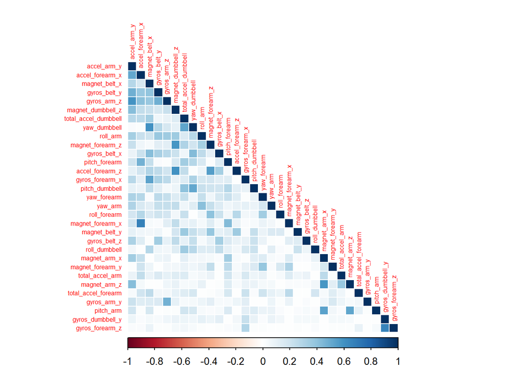

```r
ColClasse<-which(colnames(training)=="classe")
corMarix<-abs(cor(training[,-ColClasse]))
corrplot(corMarix, order="FPC",type="lower",method="color",tl.cex=0.5)
```

```r
pp <- preProcess(training[,-ColClasse],
                     method = c("center", "scale","YeoJohnson"))
training<-predict(pp, newdata = training)
test <-predict(pp, newdata = test)
```

We will alow multi core calculation to speed up the calculation, and We will use the Random Forest model to predict the manner in which the exercise is done.

```r
library(doParallel)
registerDoSEQ()
cl<-makeCluster(detectCores(),type="PSOCK")
registerDoParallel(cl)
RFmodFit <- train(classe ~ ., data = training, method = "rf")
stopCluster(cl)
```

## Acurracy and Confusion Matirx

We predict with the result of the calculated model with the test data and check the Accuracy we obtain.

```r
RFPredict<-predict(RFmodFit,test)
cmRF<-confusionMatrix(RFPredict,test$classe)
cmRF$overall["Accuracy"]
```

```
## Accuracy
## 0.986746
```

The confusion matrix with the results of apling the model to the test dataset.

```r
cmRF
```

```
## Confusion Matrix and Statistics
##
##           Reference
## Prediction    A    B    C    D    E
##          A 1673   16    0    0    0
##          B    1 1118   12    0    0
##          C    0    5 1008   33    2
##          D    0    0    6  931    3
##          E    0    0    0    0 1077
##
## Overall Statistics
##
##                Accuracy : 0.9867
##                  95% CI : (0.9835, 0.9895)
##     No Information Rate : 0.2845
##     P-Value [Acc > NIR] : < 2.2e-16
##
##                   Kappa : 0.9832
##  Mcnemar's Test P-Value : NA
##
## Statistics by Class:
##
##                      Class: A Class: B Class: C Class: D Class: E
## Sensitivity            0.9994   0.9816   0.9825   0.9658   0.9954
## Specificity            0.9962   0.9973   0.9918   0.9982   1.0000
## Pos Pred Value         0.9905   0.9885   0.9618   0.9904   1.0000
## Neg Pred Value         0.9998   0.9956   0.9963   0.9933   0.9990
## Prevalence             0.2845   0.1935   0.1743   0.1638   0.1839
## Detection Rate         0.2843   0.1900   0.1713   0.1582   0.1830
## Detection Prevalence   0.2870   0.1922   0.1781   0.1597   0.1830
## Balanced Accuracy      0.9978   0.9894   0.9871   0.9820   0.9977
```

## Most significant predictors

We want no show what are the most significant predictor used in our model, we can see it in the graph below.

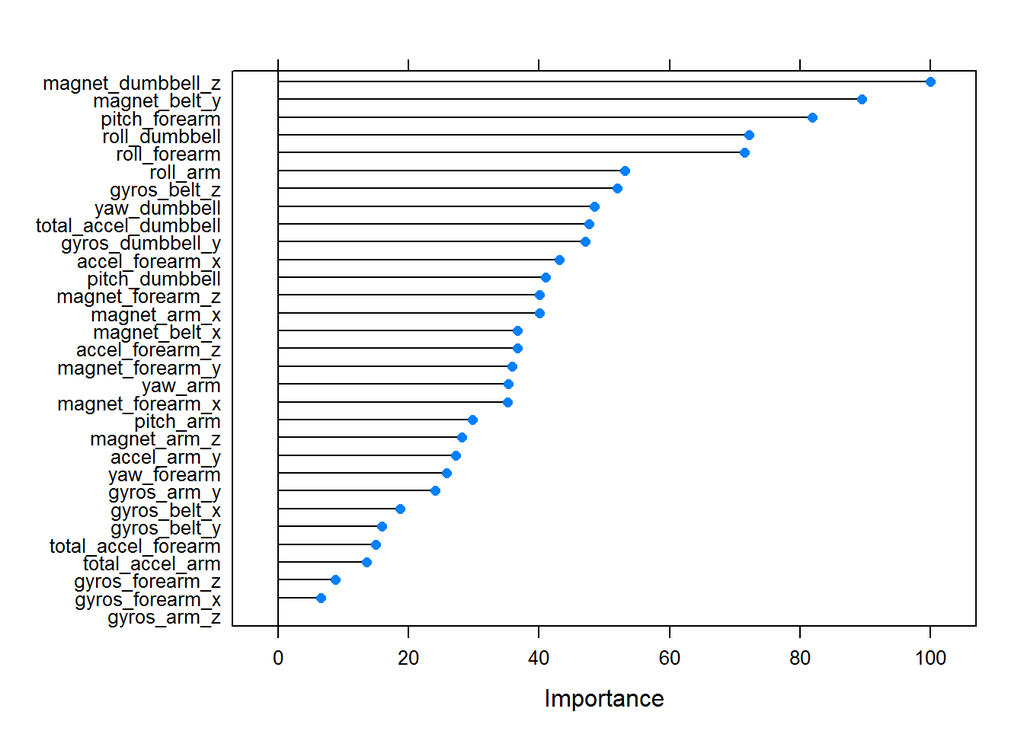

```r
RocImp <- varImp(RFmodFit)
plot(RocImp)
```

[figure not shown]

```r
qplot(RFPredict,test$classe,xlab="Real values",ylab="Predicted values",geom = c("boxplot", "jitter"),colour=test$class)
```

```r
quiz <-predict(pp, newdata = quiz)
quiz$classe<-predict(RFmodFit,quiz)
quiz$classe
```

```
##  [1] B A B A A E D B A A B C B A E E A B B B
## Levels: A B C D E
```

```r
sessionInfo ()
```

[output not shown]

### Credits

The data for this project come from this source: http://groupware.les.inf.puc-rio.br/har. If you use the document you create for this class for any purpose please cite them as they have been very generous in allowing their data to be used for this kind of assignment.